# Simple Maize Model 🌽 📈

**Calibrating `Tb`, `TTM`, and `TTL`**

To calibrate the maize model, you will work with the in-season data from Europe. Submit a script (either an R Markdown .Rmd file or R script .R) with the code needed to complete all steps outlined below, as well as answers to the Pause, Think, Discuss questions at the end. You should use the user-defined function `maize_model()` that you worked with in the last assignment. I’ve also provided my `maize_model()` code for reference, and you may choose to use mine instead of your own (but you’re encouraged to use your own!).

Before getting started, consider the following questions:

- **What data should be used for calibration?** Leave-one-out cross-validation would be the most ideal strategy in this case since we only have a few corn yield observations. However, for this exercise, you should use all data for calibration.
- **How many parameters should be estimated through calibration? Which ones?** If we were to follow the general guideline that recommends having ~20 observations per calibrated parameter, we wouldn’t have enough data for to calibrate even one parameter! For this exercise, we’ll focus on the three parameters related to temperature: `Tbase`, `TTM`, and `TTL`.
- **Which state variable(s) should be the focus of calibration efforts?** The answer to this question is dependent on the particular application for which you are running the model. In this case, we are interested in corn biomass (`B`).

Maize model code for reference:

```r
# Maize model function ----
maize_model <- function(weather_data, Tb_parameter, TTM_parameter, TTL_parameter, K_parameter, RUE_parameter, a_parameter, LAIm_parameter, TT0, LAI0, B0, start, end) {
  # Create time vector ----
  t <- seq(from = start, to = end, by = 1)

  # Define parameters ----
  # Baseline temperature for growth [deg. C]
  Tb <- Tb_parameter
  # Temperature sum for crop maturity [deg.C/day]
  TTM <- TTM_parameter
  # Temperature sum at the end of leaf area increase [deg.C/day]
  TTL <- TTL_parameter
  # Extinction coefficient [--]
  K <- K_parameter
  # Radiation use efficiency [g/MJ]
  RUE <- RUE_parameter
  # The relative rate of LAI increase for small values of LAI [deg.C/day]
  a <- a_parameter
  # Maximum LAI [m3/m3]
  LAIm <- LAIm_parameter

  # Initialize state variables ----
  # Thermal time age of the crop on day t [deg. C days]
  TT <- rep(NA, 365)
  # Leaf area index [m3/m3]
  LAI <- rep(NA, 365)
  # Biomass of the crop per square meter of ground area [g/m2]
  B <- rep(NA, 365)

  # Initial values for state variables ----
  TT[start] <- TT0
  LAI[start] <- LAI0
  B[start] <- B0

  # Run simulation
  for (day in t[1:(length(t)-1)]) {
    # Calculate rates of change
    dTT <- max((weather_data$Tmin[day] + weather_data$Tmax[day])/2 - Tb, 0)
    if(TT[day] <= TTM) {dB <- RUE * (1-exp(-K * LAI[day])) * weather_data$I[day]}
    else {dB <- 0}
    if (TT[day] <= TTL) {dLAI <- a * dTT * LAI[day] * max(LAIm - LAI[day], 0)}
    else {dLAI <- 0}

    # Update state variables
    TT[day + 1] <- TT[day] + dTT
    LAI[day + 1] <- LAI[day] + dLAI
    B[day + 1] <- B[day] + dB
  }

  # Summarize model data
  outputs <- data.frame(day = weather_data$day[t], TT = TT[t], LAI = LAI[t], B = B[t])

  return(outputs)
}
```

### Calibrate the model

- **Estimate initial values for the calibration parameters**. When we provide initial values, we are giving the algorithm a starting point. It is in our interest to choose initial values that are as close as possible to what we expect the calibrated parameters to be, as this will increase the rate at which the algorithm converges on the optimized parameters. To select initial values, it often makes sense to use literature-defined values as starting points. In this example, we will use the parameter values previously provided to us: 7 for `Tbase`, 1200 for `TTM`, and 700 for `TTL`. The initial values argument should be a vector created with `c()`.

```r
initial_values <- c(7, 1200, 700)
```

- **Creating an error function: `biomass_error`**. The error function, `biomass_error`, will produce the SSE for maize model. The `optim` function will then loop through parameter values to identify the values at which the sum of squared errors is minimized. The `biomass_error` function will require the following arguments: `parameters`, `observed_responses`, and `explanatory_variables`. `parameters` should include the **initial values** of the parameters we’re calibrating (Tb, TTM, TTL). `observed_responses` and `explanatory_variables` will correspond to our observations and weather data, respectively. Parameter values are shown below (excluding those that are being calibrated):

```r
# Extinction coefficient [--]
K <- 0.7
# Radiation use efficiency [g/MJ]
RUE <- 1.85
# The relative rate of LAI increase for small values of LAI [deg.C/day]
a <- 0.00243
# Maximum LAI [m3/m3]
LAIm <- 7
# Initial values for state variables
TT0 <- 0
LAI0 <- 0.1
B0 <- 1
# Time vector information
start <- 1
end <- nrow(explanatory_variables)
```

- **Calibrate**. To calibrate the model, use a general purpose optimization function: `optim()`. Remember, calibration is equivalent to optimization with an objective of minimizing model error. The `optim()` function requires a few arguments:
  - `par`: The initial values of the parameters that you are optimizing. In the current example, the initial values would be estimates of `Tb`, `TTM`, and `TTL`.
  - `fn`: The function we’re optimizing. In this case, we’ll need to create a new function that returns the sum of squared error (SSE) of our model since our objective will be to minimize SSE. The `optim()` function will then use this SSE function to minimize the model error by identifying optimal parameter values for `Tb`, `TTM`, and `TTL`.
  - `gr`: A function to establish the gradient for the optimization algorithm. We will assign this argument to `NULL`.
  - `method`: There are a variety of optimization approaches the `optim()` function can use. In this case, we’ll use `method = "Nelder-Mead"`.

  Apply the `optim()` function. The outputs of the `optim()` function are provided below so you can check your work.

```
## $par
## [1]   11.5452 1193.0052  708.7000
##
## $value
## [1] 132933
##
## $counts
## function gradient
##      101       NA
##
## $convergence
## [1] 0
##
## $message
## NULL
```

The elements of this output that are of interest to us include `par`, which contains the values of the calibrated parameters: Tb = 11.55, TTM = 1193.01, TTL = 708.7. `value` corresponds to the sum of squared error of the model with the calibrated parameters (ss = 132933). The other parts of the output provide information about the optimization. For example, the `optim()` function iterated 101 times until finding the optimal parameters. For more details on the output, read the help page: `help(optim)`.

### Apply the calibrated model

Run the uncalibrated model to establish the model’s baseline performance.

```r
# Run baseline simulation for uncalibrated model
simulation <- maize_model(weather_data = weather,
                          Tb_parameter = 7,
                          TTM_parameter = 1200,
                          TTL_parameter = 700,
                          K_parameter = 0.7,
                          RUE_parameter = 1.85,
                          a_parameter = 0.00243,
                          LAIm_parameter = 7,
                          TT0 = 0,
                          LAI0 = 0.1,
                          B0 = 1,
                          start = 1,
                          end = nrow(weather))
```

```r
# Calculate model efficiency: Uncalibrated
sim_obs <- left_join(observations, simulation)
EF_uncalibrated <- 1 - (sum((sim_obs$Bobs - sim_obs$B)^2)) / (sum((sim_obs$Bobs - mean(sim_obs$Bobs))^2))
EF_uncalibrated
```

```
## [1] 0.5315657
```

```r
# Run the calibrated model
simulation_calibrated <- maize_model(weather_data = weather,
                                     Tb_parameter = cal$par[1],
                                     TTM_parameter = cal$par[2],
                                     TTL_parameter = cal$par[3],
                                     K_parameter = 0.7,
                                     RUE_parameter = 1.85,
                                     a_parameter = 0.00243,
                                     LAIm_parameter = 7,
                                     TT0 = 0,
                                     LAI0 = 0.1,
                                     B0 = 1,
                                     start = 1,
                                     end = nrow(weather))
```

```r
# Calculate model efficiency: Calibrated
sim_obs_cal <- left_join(observations, simulation_calibrated)
EF_calibrated <- 1 - (sum((sim_obs_cal$Bobs - sim_obs_cal$B)^2)) / (sum((sim_obs_cal$Bobs - mean(sim_obs_cal$Bobs))^2))
EF_calibrated
```

```
## [1] 0.9822028
```

As you can see, there is a huge improvement in model efficiency when applying the calibrated model (0.53 to 0.98). Next, visualize the calibrated and uncalibrated model outputs. Plot the uncalibrated model as a dotted red line.

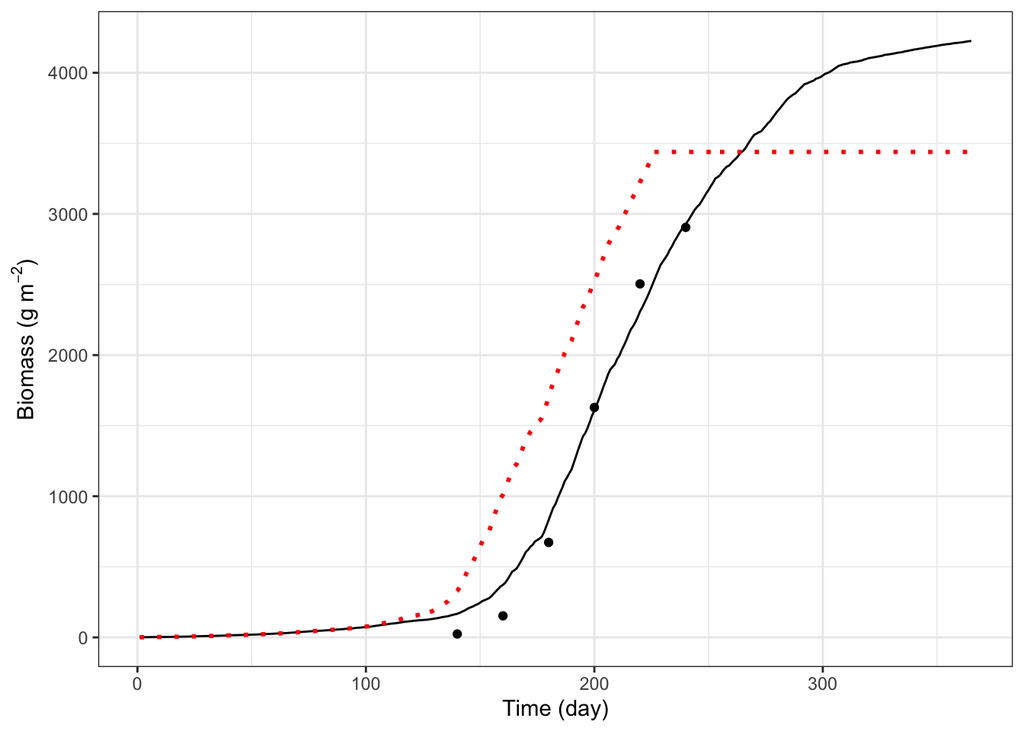

```r
# Plot observations and simulated data from the calibrated and baseline models
ggplot() +
  geom_line(data = simulation_calibrated, aes(x = day, y = B)) +
  geom_line(data = simulation, aes(x = day, y = B),
            color = 'red', linetype = 'dotted', size = 1) +
  geom_point(data = observations, aes(x = day, y = Bobs)) +
  theme_bw() +
  labs(x = "Time (day)",
  y = expression("Biomass (g "*m^{-2}*")"))
```

**Pause, think, discuss:**

In your script file, answer the following questions in at least 4 sentences:

- *Goodness-of-fit* - Does the increase in predictive performance justify calibration in this case? Why or why not?
- *Interpreting the calibrated parameters* - How did the calibrated parameters differ from the literature-defined values (`Tb = 7`, `TTM = 1200`, and `TTL = 700`)? What do you make of these differences?